# Assignment C

## Instructions

1. You may talk to a friend, discuss the questions and potential directions for solving them. However, you need to write your own solutions and code separately, and not as a group activity.
2. Do not write your name on the assignment.
3. Write your code in the *Code* cells and your answer in the *Markdown* cells of the Jupyter notebook. Ensure that the solution is written neatly enough to understand and grade.
4. Use [Quarto](https://quarto.org/docs/output-formats/html-basics.html) to print the *.ipynb* file as HTML. You will need to open the command prompt, navigate to the directory containing the file, and use the command: `quarto render filename.ipynb --to html`. Submit the HTML file.
5. The assignment is worth 100 points, and is due on **Thursday, 9th February 2023 at 11:59 pm**.
6. **Five points are properly formatting the assignment**. The breakdown is as follows:
- Must be an HTML file rendered using Quarto (1 pt). *If you have a Quarto issue, you must mention the issue & quote the error you get when rendering using Quarto in the comments section of Canvas, and submit the ipynb file.*
- No name can be written on the assignment, nor can there be any indicator of the student’s identity—e.g. printouts of the working directory should not be included in the final submission (1 pt)
- There aren’t excessively long outputs of extraneous information (e.g. no printouts of entire data frames without good reason, there aren’t long printouts of which iteration a loop is on, there aren’t long sections of commented-out code, etc.) (1 pt)
- Final answers of each question are written in Markdown cells (1 pt).
- There is no piece of unnecessary / redundant code, and no unnecessary / redundant text (1 pt)

```python
import pandas as pd
import numpy as np
import statsmodels.formula.api as smf
import seaborn as sns
import matplotlib.pyplot as plt
import statsmodels.api as sm
```

## Model assumptions

```python
hf_train = pd.read_csv('house_feature_train.csv')
hp_train = pd.read_csv('house_price_train.csv')
```

Using *house_feature_train.csv* and *house_price_train.csv*, fit a multiple linear regression model without transformation to predict `house_price` based on `distance_MRT`, `latitude`, and `longitude`, `house_age`, and `number_convenience_stores`. Print the model summary. What is the model $R^2$?

*(1 + 1 points)*

```python
h_train = pd.merge(hp_train,hf_train)
```

```python
model = smf.ols(formula = 'house_price~distance_MRT+latitude+longitude+house_age+number_convenience_stores', data = h_train).fit()
print(model.summary())
```

```
                            OLS Regression Results
==============================================================================
Dep. Variable:            house_price   R-squared:                       0.567
Model:                            OLS   Adj. R-squared:                  0.558
Method:                 Least Squares   F-statistic:                     70.32
Date:                Sun, 05 Feb 2023   Prob (F-statistic):           7.57e-47
Time:                        22:24:48   Log-Likelihood:                -2187.9
No. Observations:                 275   AIC:                             4388.
Df Residuals:                     269   BIC:                             4410.
Df Model:                           5
Covariance Type:            nonrobust
=============================================================================================
                                coef    std err          t      P>|t|      [0.025      0.975]
---------------------------------------------------------------------------------------------
Intercept                 -4.833e+05   5.79e+05     -0.835      0.404   -1.62e+06    6.56e+05
distance_MRT                 -0.2659      0.068     -3.886      0.000      -0.401      -0.131
latitude                   1.926e+04   4362.392      4.414      0.000    1.07e+04    2.78e+04
longitude                    35.8774   4570.578      0.008      0.994   -8962.778    9034.532
house_age                   -23.1472      3.786     -6.113      0.000     -30.602     -15.692
number_convenience_stores   111.8909     17.743      6.306      0.000      76.959     146.823
==============================================================================
Omnibus:                       62.033   Durbin-Watson:                   2.253
Prob(Omnibus):                  0.000   Jarque-Bera (JB):              113.606
Skew:                           1.195   Prob(JB):                     2.14e-25
Kurtosis:                       5.049   Cond. No.                     2.28e+07
==============================================================================

Notes:
[1] Standard Errors assume that the covariance matrix of the errors is correctly specified.
[2] The condition number is large, 2.28e+07. This might indicate that there are
strong multicollinearity or other numerical problems.
```

#### The model R2 is 0.567

Obtain the residuals and plot them separately against fitted values and each of the five feature variables. Make one plot including the 6 subplots.

*(4 points)*

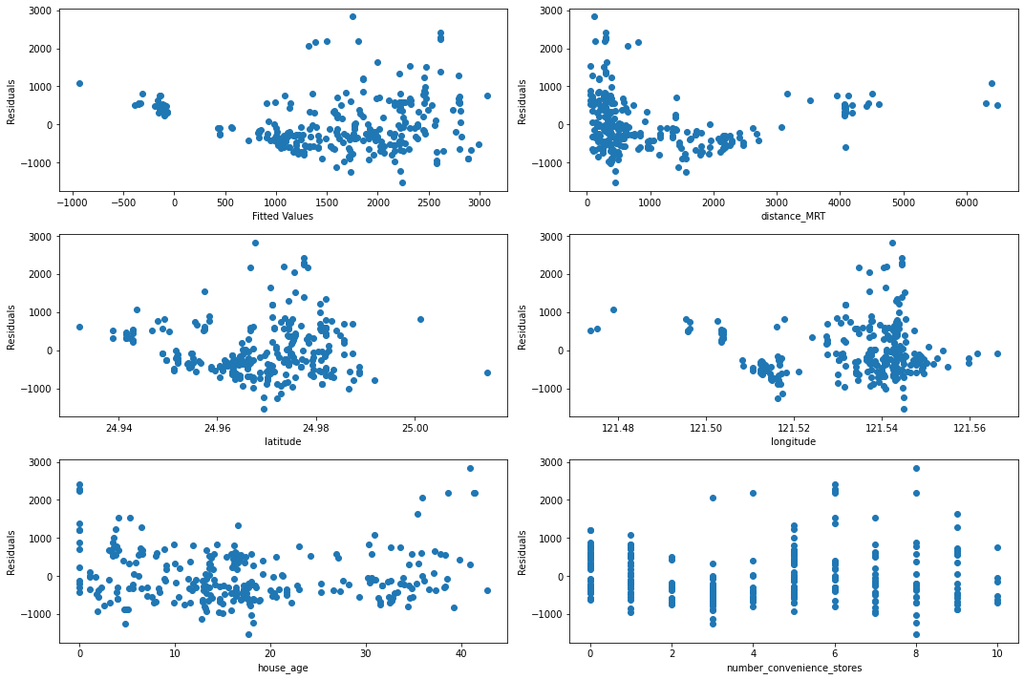

```python
# Obtain the residuals
residuals = model.resid

fig, ax = plt.subplots(2, 3, figsize=(15,10))

# Plot the residuals against the fitted values
plt.subplot(3, 2, 1)
plt.scatter(model.fittedvalues, residuals)
plt.xlabel("Fitted Values")
plt.ylabel("Residuals")

# Plot the residuals against each feature variable
plt.subplot(3, 2, 2)
plt.scatter(h_train['distance_MRT'], residuals)
plt.xlabel("distance_MRT")
plt.ylabel("Residuals")

plt.subplot(3, 2, 3)
plt.scatter(h_train['latitude'], residuals)
plt.xlabel("latitude")
plt.ylabel("Residuals")

plt.subplot(3, 2, 4)
plt.scatter(h_train['longitude'], residuals)
plt.xlabel("longitude")
plt.ylabel("Residuals")

plt.subplot(3, 2, 5)
plt.scatter(h_train['house_age'], residuals)
plt.xlabel("house_age")
plt.ylabel("Residuals")

plt.subplot(3, 2, 6)
plt.scatter(h_train['number_convenience_stores'], residuals)
plt.xlabel("number_convenience_stores")
plt.ylabel("Residuals")

plt.tight_layout()
plt.show()
```

Comment on the plot of residuals against fitted values. Does the model violate the assumption of linearity? Does the model violate the constant variance assumption?

*(2 + 2 points)*

#### Based on the plot, it does not violate the assumption of linearity because the residuals do not display a strong pattern around the line Residuals = 0. However, it does seem to violate the constant variance assumption because the variance of errors seems to increase with an increase in the fitted values.

Comment on the plot of residuals against the predictor variables. On the basis of these plots, should any further modifications of the regression model be attempted?

*(5 points)*

#### Based on my analyis of these residual plots, it seems as if distance_MRT might require some modifications it appears to violate the constance variance assumption because the variance of errors seems to be wider as the distance_MRT values decrease. It also appears that the longitude variale also violates this assumption because as longitude values increase so does the variance in errors.

Calculate the RMSE using the test datasets for the model constructed in the first question. The test datasets are *house_feature_test.csv* and *house_price_test.csv*.

*(2 points)*

```python
hf_test = pd.read_csv('house_feature_test.csv')
hp_test = pd.read_csv('house_price_test.csv')
```

```python
h_test = pd.merge(hf_test,hp_test)
```

```python
predictions = model.predict(h_test)
rmse = np.sqrt(((h_test['house_price'] - predictions)**2).mean())
print(rmse)
```

```
510.0202466830384
```

#### The RMSE is 510.02

Using appropriate transformation(s) and/or variable interaction(s), update the model to obtain a model that has a $R^{2}$ of at least 80%, and a RMSE (Root mean squared error) of at max $350k on test data.

Print the model summary and report the $R^2$, and RMSE on test data. Note:

1. House prices are provided in thousands of dollars. A value of 556 in the `house_price` column indicates a house price of $556k.
2. The test datasets are *house_feature_test.csv* and *house_price_test.csv*.
3. $R^2$ is computed on training data, and RMSE is computed on test data.
4. You must proceed logically, i.e., **justify every transformation** that you introduce into the model to improve it. If you are introducing **interactions**, there should be some rationale behind including only certain interactions in the model, unless you are including all possible interactions.

*(12 points for achieving the objectives + 8 points for justifications)*

```python
model = smf.ols(formula = 'np.log(house_price)~np.log(distance_MRT)*number_convenience_stores+latitude+np.log(longitude)+house_age', data = h_train).fit()
print(model.summary())
```

```
                             OLS Regression Results
===============================================================================
Dep. Variable:     np.log(house_price)   R-squared:                       0.806
Model:                             OLS   Adj. R-squared:                  0.801
Method:                  Least Squares   F-statistic:                     185.1
Date:                 Sun, 05 Feb 2023   Prob (F-statistic):           2.97e-92
Time:                         22:43:20   Log-Likelihood:                -96.339
No. Observations:                  275   AIC:                             206.7
Df Residuals:                      268   BIC:                             232.0
Df Model:                            6
Covariance Type:             nonrobust
==================================================================================================================
                                                     coef    std err          t      P>|t|      [0.025      0.975]
------------------------------------------------------------------------------------------------------------------
Intercept                                      -3087.0827   1066.697     -2.894      0.004   -5187.254    -986.912
np.log(distance_MRT)                              -0.4065      0.044     -9.294      0.000      -0.493      -0.320
number_convenience_stores                         -0.0582      0.049     -1.194      0.234      -0.154       0.038
np.log(distance_MRT):number_convenience_stores     0.0147      0.008      1.820      0.070      -0.001       0.031
latitude                                          21.4842      2.192      9.799      0.000      17.168      25.801
np.log(longitude)                                533.4094    222.811      2.394      0.017      94.727     972.092
house_age                                         -0.0108      0.002     -5.654      0.000      -0.015      -0.007
==============================================================================
Omnibus:                        5.144   Durbin-Watson:                   2.177
Prob(Omnibus):                  0.076   Jarque-Bera (JB):                7.165
Skew:                           0.028   Prob(JB):                       0.0278
Kurtosis:                       3.789   Cond. No.                     2.15e+06
==============================================================================

Notes:
[1] Standard Errors assume that the covariance matrix of the errors is correctly specified.
[2] The condition number is large, 2.15e+06. This might indicate that there are
strong multicollinearity or other numerical problems.
```

```python
#sns.regplot(x = h_train.distance_MRT, y =np.log(h_train.house_price),color = 'orange', line_kws = {'color':'blue'})
```

```python
predictions = model.predict(h_test)
rmse = np.sqrt(((h_test.house_price - np.exp(predictions))**2).mean())
print(rmse)
```

```
342.42854189630026
```

#### Based on the residual plots, I decided to include a few transformations. Because the subplots that plotted the fitted values, distance_MRT values, and longitude values all appeared to violate the constant variance of error terms assumption, I added a logarithmic transformation to the response variable as well as the distance_MRT and longitude variables. I also only decided to include an interaction term between distance_MRT and number_convenience stores because I thought that a closer distance to MRT would be associated with a higher density of convenience stores in a given area.

Are the assumptions of linearity and constant variance of errors satisfied in the model developed in the previous question? Make a scatterplot between the residuals and fitted values and use it to answer the question.

*(4 points)*

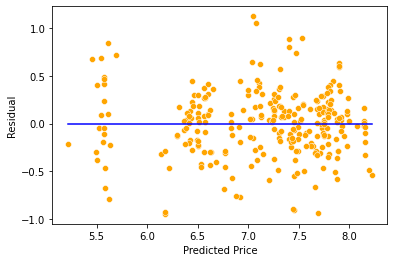

```python
sns.scatterplot(x=model.fittedvalues, y=model.resid, color='orange')
sns.lineplot(x = [model.fittedvalues.min(),model.fittedvalues.max()],y = [0,0],color = 'blue')
plt.xlabel('Predicted Price')
plt.ylabel('Residual')
plt.show()
```

#### I believe both model assumptions are satisfied in this scenario. There appears to be no discernible pattern in the plot which indicates the linearity assumption has not been violated. Additionally, the variance in residuals does not seem to increase as the predicted price values move closer to the upper and lower limit values, so the constant variance in error terms assumptions appears to not have been violated.

## Multicollinearity and Outliers

The datasets *Austin_Affordable_Housing_Train.csv* and *Austin_Affordable_Housing_Test.csv* provide data on housing development projects that have received funding from the Affordable Housing Development Fund in Austin, Texas. The city provides property developers with tax credits and other forms of funding in exchange for agreements to set housing prices (e.g. rent) below market rate.

Each row represents a housing development in Austin. Variables include the amount (USD) provided by the city, the status of the housing project, the number of housing units, the period of affordability, and more.

Let’s say that you’re hired by the city as a consultant to work with subject matter experts in their Housing and Planning Department.

*General Hint:* For written sections, writing “it depends” (along with an explanation) often characterizes a good answer.

**Note for Grading Team:** Written answers should be given full credit as long as they’re thoughtful answers that address the question fully, base findings on relevant data/results, and align with the relevant regression theory/thinking. Many questions don’t have a single right answer and/or depend on context that isn’t provided here.

```python
housing_train = pd.read_csv('Austin_Affordable_Housing_Train.csv')
housing_test = pd.read_csv('Austin_Affordable_Housing_Test.csv')
```

Suppose you run the code `status_vars = pd.get_dummies(housing_dataframe["Status"])`, append the columns of `status_vars` to your original data frame, and use the columns as predictors in a linear regression model. What potential problem would you likely be introducing into the model? How could it affect your results?

*(4 points)*

#### There might be a problem with multicollinearity which can affect the interpretation of the coefficients in the linear regression model. In this case, the one-hot encoded variables for the “Status” column will likely be highly correlated with each other, since each status is exclusive to each housing development project which will affect the interpretability and stability of the coefficients in the linear regression model.

Suppose that a subject matter expert recommends using the variables `Total_Units`, `Total_Affordable_Units`, `Total_Accessible_Units`, and `Market_Rate_Units` as predictors in your model. From a regression modeling standpoint, does this sound advisable? Produce metrics to quantify the potential impact of including the four predictors in a model. Interpret at least one of the metrics you provide, both statistically and in the context of the problem.

*(4 points)*

```python
from statsmodels.stats.outliers_influence import variance_inflation_factor
from statsmodels.tools.tools import add_constant
X = housing_train[['Total_Units','Total_Affordable_Units','Total_Accessible_Units','Market_Rate_Units']]
X = add_constant(X)
vif_data = pd.DataFrame()
vif_data['predictor'] = X.columns
for i in range(len(X.columns)):
    vif_data.loc[i,'VIF'] = variance_inflation_factor(X.values,i)
print(vif_data)
## th
```

```
                predictor         VIF
0                   const    1.245882
1             Total_Units  234.528279
2  Total_Affordable_Units  159.751905
3  Total_Accessible_Units    2.033927
4       Market_Rate_Units   40.571755
```

#### The predictor variable Total_Units has a VIF value of 234.5, indicating that there is a very high degree of collinearity between this variable and the other predictor variables. This also applies to the Total_Affordable_Units variable with a VIF value of 159.8. Since these values are high, we should investigate the collinearity between the predictor variables and perhaps consider dropping some of the predictor variables if necessary, as high collinearity can affect the reliability of the model.

Say that the subject matter expert agrees to use `Total_Affordable_Units`, `Affordability_Expiration_Year`, and `Units_Under_50_Percent_MFI` as predictors for `City_Amount`. Fit the appropriate model (without transformations). Then interpret the results associated with `Total_Affordable_Units`, and comment on the overall model fit.

*(4 points)*

```python
ols_object = smf.ols(formula = 'City_Amount~Total_Affordable_Units+Affordability_Expiration_Year+Units_Under_50_Percent_MFI', data = housing_train)
model = ols_object.fit()
print(model.summary())
```

```
                            OLS Regression Results
==============================================================================
Dep. Variable:            City_Amount   R-squared:                       0.491
Model:                            OLS   Adj. R-squared:                  0.483
Method:                 Least Squares   F-statistic:                     63.08
Date:                Sun, 12 Feb 2023   Prob (F-statistic):           1.37e-28
Time:                        21:32:30   Log-Likelihood:                -3056.1
No. Observations:                 200   AIC:                             6120.
Df Residuals:                     196   BIC:                             6133.
Df Model:                           3
Covariance Type:            nonrobust
=================================================================================================
                                    coef    std err          t      P>|t|      [0.025      0.975]
-------------------------------------------------------------------------------------------------
Intercept                     -8.409e+06   4.35e+06     -1.933      0.055    -1.7e+07    1.72e+05
Total_Affordable_Units         2.261e+04   2059.042     10.983      0.000    1.86e+04    2.67e+04
Affordability_Expiration_Year  4233.1306   2125.847      1.991      0.048      40.661    8425.600
Units_Under_50_Percent_MFI    -8946.2892   3784.569     -2.364      0.019   -1.64e+04   -1482.585
==============================================================================
Omnibus:                      137.743   Durbin-Watson:                   1.366
Prob(Omnibus):                  0.000   Jarque-Bera (JB):             3152.792
Skew:                           2.171   Prob(JB):                         0.00
Kurtosis:                      21.960   Cond. No.                     1.19e+05
==============================================================================

Notes:
[1] Standard Errors assume that the covariance matrix of the errors is correctly specified.
[2] The condition number is large, 1.19e+05. This might indicate that there are
strong multicollinearity or other numerical problems.
```

```python
pred_price = model.predict(housing_test)
np.sqrt(((housing_test.City_Amount - pred_price)**2).mean())
```

```
787388.3685514104
```

#### With respect to the Total_Affordable_Units variable, the coeffcient indicates that a one unit increase in the amount of affordable units is expected to increase the amount of USD provided by the city by $22,610. The p-value of this variable is 0 so this effect is statistically significant at almost all significant levels.

#### However, when assessing the overall model fit the model does not perform well, despite the fact that overall model is significant based on the p-value of the F-statistic. The R2 value is 0.491, meaning that less half of the variation in the City_Amount variable is explained by the variation in the model’s predictors.

Using visualizations, investigate whether the model you fit in in the previous question yields outlying observations. What count and proportion of observations would you classify as outliers?

Note: Show separate plots for both - residuals and studentized residuals. However, consider studentized residuals when identifying outliers.

*(4 points)*

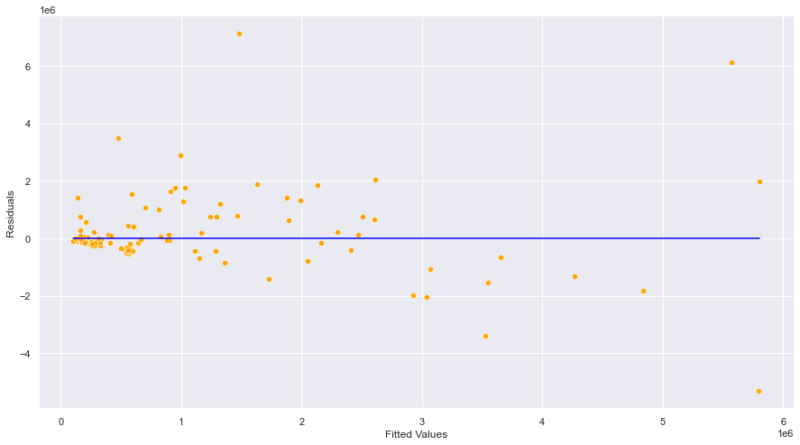

```python
sns.scatterplot(x=model.fittedvalues, y=model.resid, color='orange')
sns.lineplot(x = [model.fittedvalues.min(),model.fittedvalues.max()],y = [0,0],color = 'blue')
plt.xlabel('Fitted Values')
plt.ylabel('Residuals')
plt.show()
```

```python
out = model.outlier_test()
```

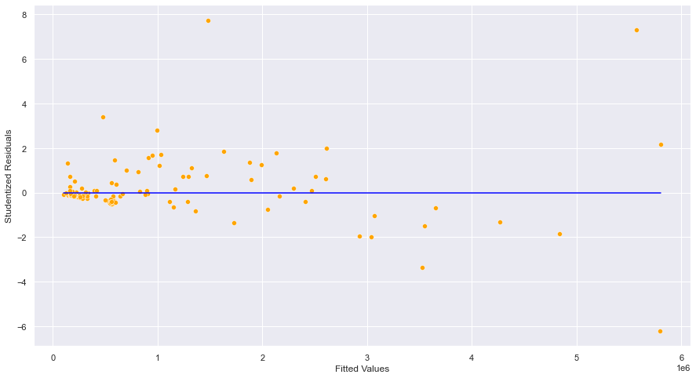

```python
sns.scatterplot(x=model.fittedvalues, y=out.student_resid, color='orange') #fittedvalues gives predicted values for trainig data
sns.lineplot(x = [model.fittedvalues.min(),model.fittedvalues.max()],y = [0,0],color = 'blue')
plt.xlabel('Fitted Values')
plt.ylabel('Studentized Residuals')
plt.show()
```

```python
outliers = (np.sum(np.abs(out.student_resid) > 3))
num_observations = model.fittedvalues.shape[0]
print("Total number of observations:", num_observations)
print("Total number of outliers:", outliers)
print("Proportion of outliers:", outliers/num_observations)
```

```
Total number of observations: 200
Total number of outliers: 5
Proportion of outliers: 0.025
```

#### Total number of observations: 200

#### Total number of outliers: 5

#### Proportion of outliers: 0.025

Based on your results in the previous question, would you choose to remove outlying observations? Why or why not?

*(4 points)*

#### It depends but I would not choose to remove the outliers. For one, only a small proportion of the observations are outliers in the dataset and the predictor variables are all significant at a 0.05 significance level. Also, looking into the data and plotting a scatterplot between Total_Affordable_Units and City_Amount reveals that there are some very high values of City_Amount at higher levels of Total_Affordable_Units. Even though the model fit is poor based on the R2, I don’t have reason to believe that the outliers are caused by incorrect data. We might be able to fix R2 by adding more meaningful predictors to the model.

Consider a scenario in which the model will be used by property owners seeking to predict the amount of money they may receive from the city of Austin. How would this change, support, or complicate your answer in the previous question, if at all?

*(3 points)*

#### It depends on the distinction between property owners and property developers. Assuming that these two entities are distinct, I think it’s fine to keep the outliers in this scenario. This is because many of the outliers are on the higher end of the dataset, especially when plotting the association between City_Amount and Total_Affordable_Units. Property owners are more likely to fall into housing developments with more average values for predictors such as Total_Affordable_Units. Property owners care more about these general trends which aren’t extremely altered by outliers in the dataset.

Say that the model will be used by a team of sociologists seeking statistical evidence at the $\alpha = 0.01$ significance level that a property’s affordability expiration year has an effect on the amount of money issued by the city of Austin? How would this change, support, or complicate your answer in C.2.5, if at all?

*(3 points)*

#### If were are looking for evidence at this statistical level, then it would be advisable to remove outliers. As it stands with the current model, the p-value for Affordability_Expiration_Year is greater than 0.01 which would make it a non-significant predictor. Removing these outliers could possiblly reduce the standard error of this variable’s coefficient and increase decrease its p-value closer to the desired significance level.

Determine whether the model you fit in C.2.3 contains any high-leverage points. Produce a visualization, then report the count and proportions of observations that are high-leverage *(define an observation as “high-leverage” if its leverage is greater than four times the average leverage of all observations)*.

*(4 points)*

```python
influence = model.get_influence()
leverage = influence.hat_matrix_diag
```

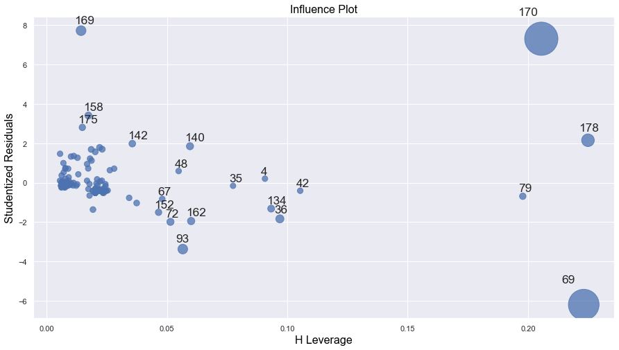

```python
sns.set(rc={'figure.figsize':(15,8)})
sm.graphics.influence_plot(model);
```

```python
cutoff = 4*((model.df_model+1)/(model.nobs))
high_lvg = np.sum(leverage > cutoff)
num_observations = model.fittedvalues.shape[0]
print("Number of high-leverage points:", high_lvg)
print("Number of observations:", num_observations)
print("Proportion of high-leverage points:", high_lvg/num_observations)
```

```
Number of high-leverage points: 8
Number of observations: 200
Proportion of high-leverage points: 0.04
```

#### Number of high-leverage points: 8

#### Number of observations: 200

#### Proportion of high-leverage points: 0.04

Based on your results in the previous question, would you choose to remove high-leverage observations? Why or why not?

*(3 points)*

#### It depends but I would probably choose not to remove them. The visualization and calculation seems to indicate that only a small proportion of the observations can be classified as high-leverage and only two of these points seems to be influential based on the sizez of the circles in the visualization. I think I would be omitting necessary data in order to get rid of these influential points and this is not the correct choice in my opinion. It would also not be necessary to remove the observations if they lie on the regression line or plane.

Identify and remove any influential points from the training data and refit the model. How does removing influential affect the model, if at all?

Think about using the model summary, and use the test data provided.

*(6 points)*

```python
train_filtered = housing_train.drop(np.intersect1d(np.where(np.abs(out.student_resid)>3)[0],
                                           (np.where(leverage>cutoff)[0])))
print("Number of influential points:", housing_train.shape[0] - train_filtered.shape[0])
```

```
Number of influential points: 2
```

#### Number of influential points: 2

```python
ols_object = smf.ols(formula = 'City_Amount~Total_Affordable_Units+Affordability_Expiration_Year+Units_Under_50_Percent_MFI', data = train_filtered)
model = ols_object.fit()
print(model.summary())
```

```
                            OLS Regression Results
==============================================================================
Dep. Variable:            City_Amount   R-squared:                       0.504
Model:                            OLS   Adj. R-squared:                  0.497
Method:                 Least Squares   F-statistic:                     65.77
Date:                Sun, 12 Feb 2023   Prob (F-statistic):           2.20e-29
Time:                        21:30:22   Log-Likelihood:                -2991.3
No. Observations:                 198   AIC:                             5991.
Df Residuals:                     194   BIC:                             6004.
Df Model:                           3
Covariance Type:            nonrobust
=================================================================================================
                                    coef    std err          t      P>|t|      [0.025      0.975]
-------------------------------------------------------------------------------------------------
Intercept                     -8.381e+06   3.66e+06     -2.289      0.023   -1.56e+07   -1.16e+06
Total_Affordable_Units          2.17e+04   2272.150      9.550      0.000    1.72e+04    2.62e+04
Affordability_Expiration_Year  4219.4469   1788.564      2.359      0.019     691.921    7746.973
Units_Under_50_Percent_MFI    -7698.1883   3746.489     -2.055      0.041   -1.51e+04    -309.109
==============================================================================
Omnibus:                      178.422   Durbin-Watson:                   1.709
Prob(Omnibus):                  0.000   Jarque-Bera (JB):             4872.165
Skew:                           3.211   Prob(JB):                         0.00
Kurtosis:                      26.438   Cond. No.                     1.19e+05
==============================================================================

Notes:
[1] Standard Errors assume that the covariance matrix of the errors is correctly specified.
[2] The condition number is large, 1.19e+05. This might indicate that there are
strong multicollinearity or other numerical problems.
```

```python
pred_price = model.predict(housing_test)
np.sqrt(((housing_test.City_Amount - pred_price)**2).mean())
```

```
778947.8973204924
```

#### Based on the new model, there seems to be some modest effect on the model when implemented on the filtered dataset. One predictor (Affordability_Expiration_Year) becomes a much more significant predictor whereas the Units_Under_50_Percent_MFI predictor becomes less significant. This tradeoff is connected to only a small increase the model’s R2 value. This indicates that the model’s overall fit has not improved. Also, the RMSE is a bit lower with this new model, but not enough to say that removing the influential points from the training data significantly improved the model’s predictive ability.

## Autocorrelation

Refer to the autocorrelation example in the [class notes](https://nustat.github.io/STAT303-2-class-notes/Lec6_Autocorrelation.html). Predict the power consumption for each hour of each day of the year 2020. For predicting a power consumption on a particular hour of a day, use all the data you have until the previous day. However, don’t use any data of the day on which you are making the predictions. For example, for making 24 predictions for each hour of 4th April, 2020, use all the data upto 3rd April 2020. Make the predictions using four different models:

1. Model with only `temp_hot` and `temp_cold` as the predictors
2. Model including one day lag of power as a predictor in addition to the predictors in model (1)
3. Model including one week lag of power as a predictor in addition to the predictors in model (2)
4. Model including two weeks lag of power as a predictor in addition to the predictors in model (3)

For each model:

1. Report the RMSE for the predicted power in 2020. You should have 366 x 24 = 8784 predicted values of power for each model.
2. Make a scatterplot of predicted power vs actual power *(use color = ‘orange’)*. Plot the line x = y over the scatterplot *(use color = ‘blue’)*.

Which model makes the most accurate predictions?

*(4 points for developing the models + 4 points for computing the predictions + 4 points for computing the RMSEs + 2 points for the visualizations + 1 point for identifying the most accurate model)*

```python
%pylab inline
import pandas as pd
import seaborn as sns
import statsmodels.api as sm
plt.rcParams['figure.figsize'] = [9, 5]
```

```python
df = pd.read_csv('Toronto_power_demand.csv', parse_dates=['Date'], index_col = 0)
df['temperature'] = df['temperature'].shift(24*1)
is_hot = (df['temperature']>15).astype(int)
df['temp_hot'] = df['temperature']*is_hot
df['temp_cold'] = df['temperature']*(1-is_hot)
```

```python
# A few helper functions
import numpy.ma as ma
from scipy.stats.stats import pearsonr, normaltest
from scipy.spatial.distance import correlation
def build_model(features,date):
  X=sm.add_constant(df.loc[df['Date']<date][features])
  y=df.loc[df['Date'] < date]['power']
  model = sm.OLS(y,X, missing='drop').fit()
  x_test = sm.add_constant(df.loc[df.Date==date][features])
  predictions = model.predict(x_test)
  #display(model.summary())
  res=y-predictions
  return res




def plt_residual(res):
  plt.plot(range(len(res)), res)
  plt.ylabel('Residual')
  plt.xlabel("Hour")

def plt_residual_lag(res, nlag):
  x=res.values
  y=res.shift(nlag).values
  sns.kdeplot(x,y=y,color='blue',shade=True )
  plt.xlabel('res')
  plt.ylabel("res-lag-{}".format(nlag))
  rho,p=corrcoef(x,y)
  plt.title("n_lag={} hours, correlation={:f}".format(nlag, rho))

def plt_acf(res):
  plt.rcParams['figure.figsize'] = [18, 5]
  acorr = sm.tsa.acf(res.dropna(), nlags = len(res.dropna())-1)
  fig, (ax1, ax2) = plt.subplots(1, 2)
  ax1.plot(acorr)
  ax1.set_ylabel('corr')
  ax1.set_xlabel('n_lag')
  ax1.set_title('Auto Correlation')
  ax2.plot(acorr[:4*7*24])
  ax2.set_ylabel('corr')
  ax2.set_xlabel('n_lag')
  ax2.set_title('Auto Correlation (4-week zoomed in) ')
  plt.show()
  pd.set_option('display.max_columns', None)
  adf=pd.DataFrame(np.round(acorr[:30*24],2).reshape([30, 24] ))
  adf.index.name='day'
  display(adf)
  plt.rcParams['figure.figsize'] = [9, 5]

def corrcoef(x,y):
    a,b=ma.masked_invalid(x),ma.masked_invalid(y)
    msk = (~a.mask & ~b.mask)
    return pearsonr(x[msk],y[msk])[0], normaltest(res, nan_policy='omit')[1]
```

```python
range1 = df['Date'].loc[df['Date'] > '2019-12-31']
date_range = range1.loc[df['Date'] < '2021-01-01']
date_range
```

```
key
20200101:0    2020-01-01
20200101:1    2020-01-01
20200101:2    2020-01-01
20200101:3    2020-01-01
20200101:4    2020-01-01
                 ...
20201231:19   2020-12-31
20201231:20   2020-12-31
20201231:21   2020-12-31
20201231:22   2020-12-31
20201231:23   2020-12-31
Name: Date, Length: 8784, dtype: datetime64[ns]
```

```python
series1 = pd.Series(dtype = 'float64')
for x.key in date_range:
    predictions = build_model(['temp_hot', 'temp_cold'],x)
    series1 = pd.concat([series1,predictions],ignore_index=True, axis=0)
```

```python
p1 = df['power'].loc[df['Date'] > '2019-12-31']
power_range = p1.loc[df['Date'] < '2021-01-01']
```

```python
power_range
```

```
key
20200101:0     4718
20200101:1     4571
20200101:2     4443
20200101:3     4356
20200101:4     4317
               ...
20201231:19    5948
20201231:20    5741
20201231:21    5527
20201231:22    5301
20201231:23    5094
Name: power, Length: 8784, dtype: int64
```

```python
series1
```

```
0         5651.714703
1         5636.695002
2         5629.185151
3         5561.596496
4         5550.331720
             ...
210811    5317.526353
210812    5332.546054
210813    5362.585456
210814    5392.624858
210815    5422.664260
Length: 210816, dtype: float64
```

```python
d1 = df.loc[df['Date'] > '2019-12-31']
d2 = d1.loc[df['Date'] < '2021-01-01']
d2
```

| key | Date | Hour | power | temperature | temp_hot | temp_cold |
| --- | --- | --- | --- | --- | --- | --- |
| 20200101:0 | 2020-01-01 | 0 | 4718 | 2.3 | 0.0 | 2.3 |
| 20200101:1 | 2020-01-01 | 1 | 4571 | 2.3 | 0.0 | 2.3 |
| 20200101:2 | 2020-01-01 | 2 | 4443 | 1.8 | 0.0 | 1.8 |
| 20200101:3 | 2020-01-01 | 3 | 4356 | 1.9 | 0.0 | 1.9 |
| 20200101:4 | 2020-01-01 | 4 | 4317 | 1.3 | 0.0 | 1.3 |
| ... | ... | ... | ... | ... | ... | ... |
| 20201231:19 | 2020-12-31 | 19 | 5948 | 4.9 | 0.0 | 4.9 |
| 20201231:20 | 2020-12-31 | 20 | 5741 | 4.5 | 0.0 | 4.5 |
| 20201231:21 | 2020-12-31 | 21 | 5527 | 3.7 | 0.0 | 3.7 |
| 20201231:22 | 2020-12-31 | 22 | 5301 | 2.9 | 0.0 | 2.9 |
| 20201231:23 | 2020-12-31 | 23 | 5094 | 2.1 | 0.0 | 2.1 |

8784 rows × 6 columns